# Comparing Kriging, Land Use Regression (LUR), and Inverse Distance Weighting (IDW)

### R Packages

This is a list of R packages we will be using for this analysis:

```r
library(geoR) # Geostatistical analysis package
library(splancs) # Displays spatial data
```

```r
library(maps) # Displays maps
library(gstat) # Variogram modelling and kriging
library(lattice) # Multi-pane graphing package to display relationships between variables
library(ggplot2) # Graphing package
```

### Loading Soil Calcium Data

```r
data(ca20)
names(ca20)
```

```
## $coords
## [1] "east"  "north"
##
## $data
## [1] "data"
##
## $covariate
## [1] "altitude" "area"
##
## $borders
## [1] "borders"
##
## $other
## [1] "reg1" "reg2" "reg3"
```

The ‘ca20’ dataset is of class ‘geodata’. This is a custom class. It turns out that the geodata class is simply a list containing 5 named elements (references using the dollad, ‘$’ sign): 1) a matrix of coordinates, 2) a vector of integers representing the measurements taken at each coordinate (repesenting calcium levels, in this instance), 3) a dataframe containing the covariate data for each coordinate (in this instance, altitude and area), 4) a dataframe containing data needed to draw the relevant borders for this data, 5) a placeholder for other data.

```r
class(ca20)
```

```
## [1] "geodata"
```

```r
class(ca20$coords)
```

```
## [1] "matrix"
```

```r
head(ca20$coords)
```

```
##   east north
## 1 5710  4829
## 2 5727  4875
## 3 5745  4922
## 4 5764  4969
## 5 5781  5015
## 6 5799  5062
```

```r
class(ca20$data)
```

```
## [1] "numeric"
```

```r
head(ca20$data)
```

```
## [1] 52 57 72 74 68 45
```

```r
class(ca20$covariate)
```

```
## [1] "data.frame"
```

```r
head(ca20$covariate)
```

```
##   altitude area
## 1     6.10    3
## 2     6.05    3
## 3     6.30    3
## 4     6.60    3
## 5     6.60    3
## 6     5.75    3
```

```r
class(ca20$borders)
```

```
## [1] "data.frame"
```

```r
head(ca20$borders)
```

```
##    east north
## 2  5340  5800
## 1  5590  5690
## 8  5990  5690
## 11 5990  5100
## 10 5780  4800
## 9  5590  4800
```

```r
class(ca20$other)
```

```
## [1] "NULL"
```

```r
head(ca20$other)
```

### Exploratory Data Analysis

The ‘plot()’ function is from the ‘sp’ package which is a prereqisite package for geoR. ‘sp’ conains classess and methods for spatial data. The top right plot appears to show that as you go further south (‘Y Coord’), soil calcium levels appear to increase. How far north a data point is would be an interesting covariate to add to our LUR model. On the other hand, the bottom left plot seems to show no trend as you move east to west.

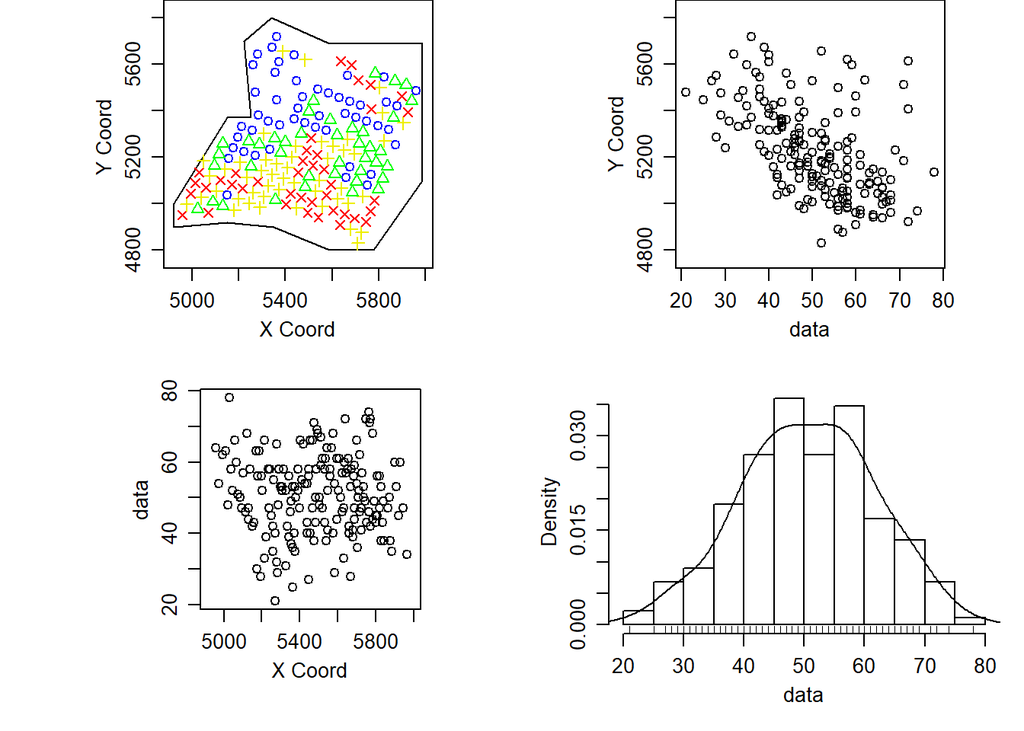

```r
plot(ca20, borders=ca20$borders)
```

### Plotting Initial Semivariogram to Assess Spatial Dependence

To plot our semivariogram we use the variog() function from geoR. By default it will take the coords and data from our geodata object and return a binned variogram (as opposed to a variogram cloud, or a smoothed variogram). In the example below, we are specifying the maximum distance for our variogram. https://www.rdocumentation.org/packages/geoR/versions/1.7-5.2.1/topics/variog. Semivariaograms, and therefore, Kriging, measure ‘small scale’ variation, i.e. the influence of the immediate surroundings of the data point.

The semivariogram below shows that there does indeed appear to be a spatial dependence for soil calcium levels.

```
## variog: computing omnidirectional variogram
```

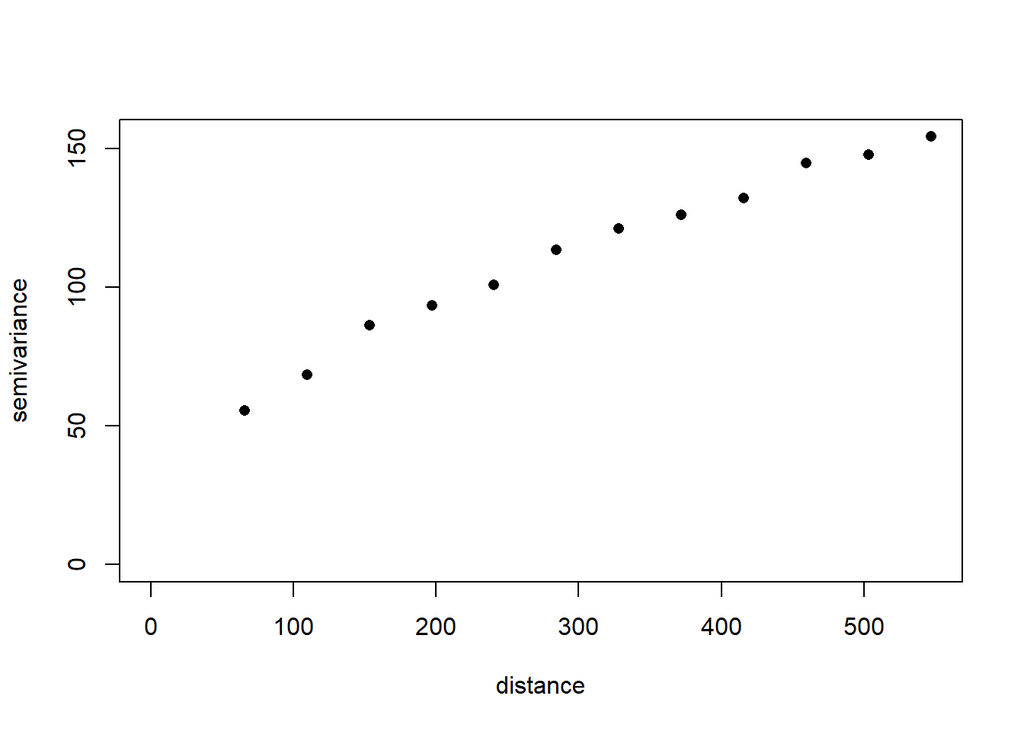

```r
plot(variog(ca20,max.dist = 1138/2),pch=16)
```

### Exploring Large-Scale Spatial Relationships (and Ignoring the Small-Scale Spatial Effect)

Looking at the relationship between calcium and altitude, it appears that higher altitude increases as you go south. This would indicate the altitude and north are correlated. This may mean that north and altitude have less ‘explanatory power’ than these numbers would suggest. In other words, because of the relationship between the two environmental covariates, less of the vaariation of the outcome may be explained than we would expect if there was not relationship between the two covariates.

It is worth noting that the matrix belwo only shows the degree of correlation, not whether the underlying relationship is statistically significant.

```r
# Let's begin by creating a dataframe out outome (soil calcium levels), and covariates (North, and altitude) to feed into our linear regression function.

CAdata = data.frame(calcium = ca20$data,
                    altitude = as.vector(ca20$covariate$altitude),
                    north = as.vector(ca20$coords[,2]))

cor(CAdata)
```

```
##             calcium   altitude      north
## calcium   1.0000000  0.2967815 -0.5198284
## altitude  0.2967815  1.0000000 -0.7544032
## north    -0.5198284 -0.7544032  1.0000000
```

To assess the statistical significance of the covariates on the outcome, let’s feed our dataframe into a few linear regression models.

```r
lm1<-lm(calcium~north,data=CAdata)
summary(lm1)
```

```
##
## Call:
## lm(formula = calcium ~ north, data = CAdata)
##
## Residuals:
##     Min      1Q  Median      3Q     Max
## -22.237  -5.370  -0.825   5.219  32.715
##
## Coefficients:
##               Estimate Std. Error t value Pr(>|t|)
## (Intercept) 203.653767  18.962809  10.740  < 2e-16 ***
## north        -0.029273   0.003626  -8.073 1.04e-13 ***
## ---
## Signif. codes:  0 '***' 0.001 '**' 0.01 '*' 0.05 '.' 0.1 ' ' 1
##
## Residual standard error: 9.492 on 176 degrees of freedom
## Multiple R-squared:  0.2702, Adjusted R-squared:  0.2661
## F-statistic: 65.17 on 1 and 176 DF,  p-value: 1.04e-13
```

```r
lm2<-lm(calcium~altitude,data=CAdata)
summary(lm2)
```

```
##
## Call:
## lm(formula = calcium ~ altitude, data = CAdata)
##
## Residuals:
##      Min       1Q   Median       3Q      Max
## -30.4906  -6.7376  -0.0526   6.8153  27.1111
##
## Coefficients:
##             Estimate Std. Error t value Pr(>|t|)
## (Intercept)   23.439      6.655   3.522 0.000545 ***
## altitude       4.931      1.196   4.123 5.75e-05 ***
## ---
## Signif. codes:  0 '***' 0.001 '**' 0.01 '*' 0.05 '.' 0.1 ' ' 1
##
## Residual standard error: 10.61 on 176 degrees of freedom
## Multiple R-squared:  0.08808,    Adjusted R-squared:  0.0829
## F-statistic:    17 on 1 and 176 DF,  p-value: 5.754e-05
```

```r
lm3<-lm(calcium~north+altitude,data=CAdata)
summary(lm3)
```

```
##
## Call:
## lm(formula = calcium ~ north + altitude, data = CAdata)
##
## Residuals:
##     Min      1Q  Median      3Q     Max
## -21.406  -5.712  -1.012   5.521  32.057
##
## Coefficients:
##               Estimate Std. Error t value Pr(>|t|)
## (Intercept) 273.114823  35.729414   7.644 1.34e-12 ***
## north        -0.038677   0.005459  -7.085 3.27e-11 ***
## altitude     -3.677905   1.610744  -2.283   0.0236 *
## ---
## Signif. codes:  0 '***' 0.001 '**' 0.01 '*' 0.05 '.' 0.1 ' ' 1
##
## Residual standard error: 9.381 on 175 degrees of freedom
## Multiple R-squared:  0.2913, Adjusted R-squared:  0.2832
## F-statistic: 35.97 on 2 and 175 DF,  p-value: 8.196e-14
```

### Comparing the Small-Scale Spatial Effect Before and After Accounting for Large Scale Spatial Effects

Below we compare our initial semivariogram with the residual semivariogram after accounting for large scale spatial effects using the linear regression model (aka Land Use Regression (LUR)).

```r
# Plot the original semivariogram (vario_ok = semivariogram that is used for Ordinary Kriging)
vario_ok = variog(ca20,max.dist=1138/2)
```

```
## variog: computing omnidirectional variogram
```

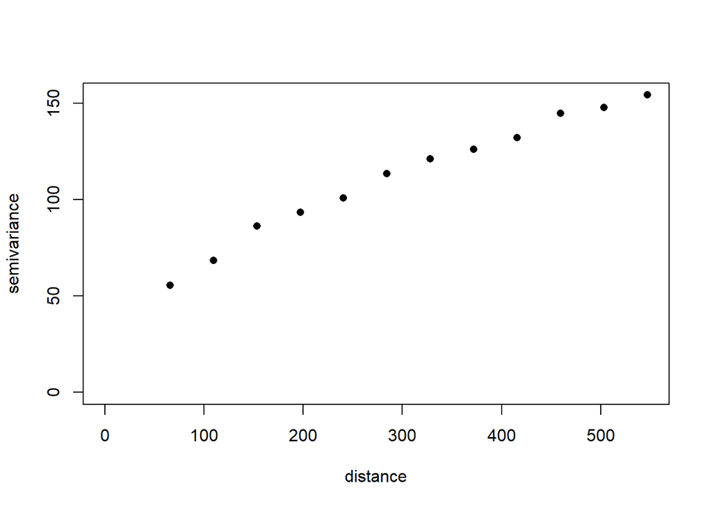

```r
plot(vario_ok,pch=16)
```

```r
#Plot the semivariogram after accounting for the two environmental covariates used in the regression model
# grab the residuals for each data point
resid = lm1$residuals
geo_lm = as.geodata(cbind(ca20$coords,resid)) # ca20$coords is written to geo_lm$coords, resid is writtent to geo_lm$data (this is the residual soil calcium level variation that was NOT accounted for by the linear model. We want to see how much of the variation in residual variation in soild calcium levels is exaplined by small scale spatial effects).
vario_lm <-variog(geo_lm,max.dist=1138/2)
```

```
## variog: computing omnidirectional variogram
```

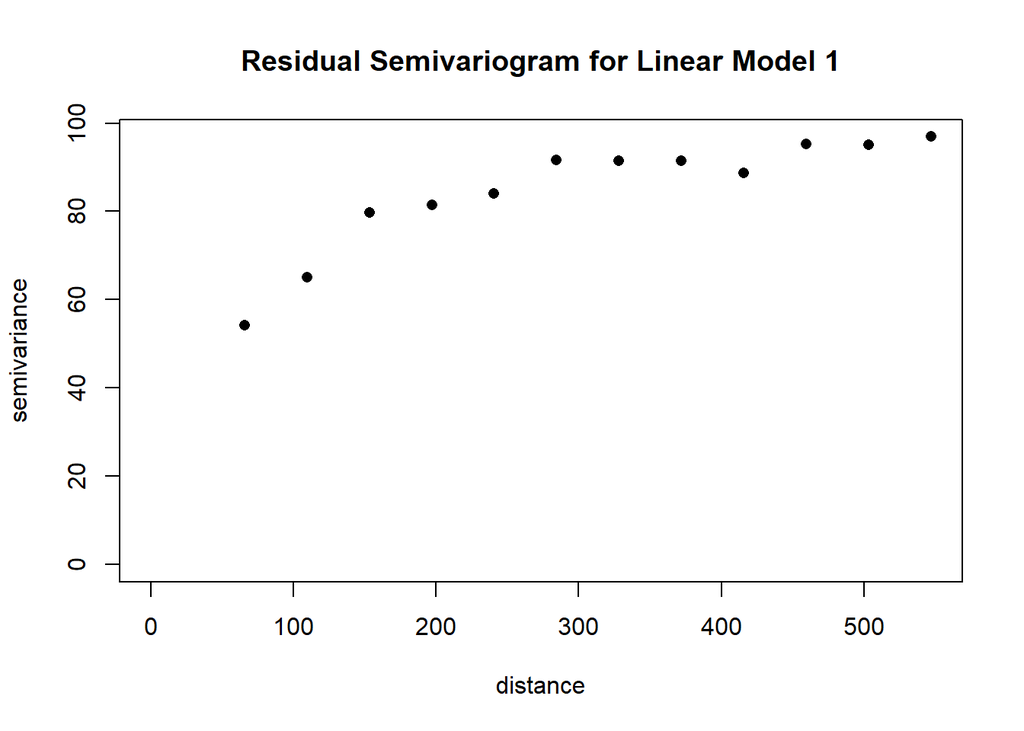

```r
plot(vario_lm,pch=16)
title("Residual Semivariogram for Linear Model 1")
```

```r
geo_lm
```

[output not shown]

[output cut: 206 more lines]

### Ordinary Kriging: Finding the line of best fit (WLS and MLE)

The first step for any Kriging model is to take the semivarigram and create a function, or ‘line of best fit’ for it. In order to do this we need to need to select the method for fitting we want to use. Apart from the standard OLS (Ordinary Least Squares) method of finding the line of best fit, there is MLE (Maximum Likelihood Estimation) and WLS (Weighted Least Squares).

```r
# Let's start by splotting the scatterplot of our semivariogram
vario_ok = variog(ca20, max.dist = 1138/2)
```

```
## variog: computing omnidirectional variogram
```

```r
plot(vario_ok, pch = 16)

# Let's find and plot the WLS line of best fit for the semivariogram
oklineofbestfitWLS = variofit(vario_ok, ini.cov.pars = c(150,200), nugget = 30, weights = "cressie") ## The parameter 'ini.cov.pars' takes a vector with the 'partial sill' and 'range' - Weights is 'cressie' is simply the way we are calculating our weighted lesast square estimate
```

```
## variofit: covariance model used is matern
## variofit: weights used: cressie
## variofit: minimisation function used: optim
```

```r
lines(oklineofbestfitWLS, lwd = 2, lty = 3)

# Let's do the same again but using MLE. likfit() is just variofit() but for MLE. MLE needs a different function because it uses different input data. Where WLS uses the points on the smivariogram (which are aggrates data points by distance bin). MLE uses the the original, unaggrefated data (data in ca20$data) to calculate variances used in the MLE calculation.
oklineofbestfitMLE = likfit(ca20, ini.cov.pars = c(170.02, 451.79), nugget = 33.12)
```

```
## ---------------------------------------------------------------
## likfit: likelihood maximisation using the function optim.
## likfit: Use control() to pass additional
##          arguments for the maximisation function.
##         For further details see documentation for optim.
## likfit: It is highly advisable to run this function several
##         times with different initial values for the parameters.
## likfit: WARNING: This step can be time demanding!
## ---------------------------------------------------------------
## likfit: end of numerical maximisation.
```

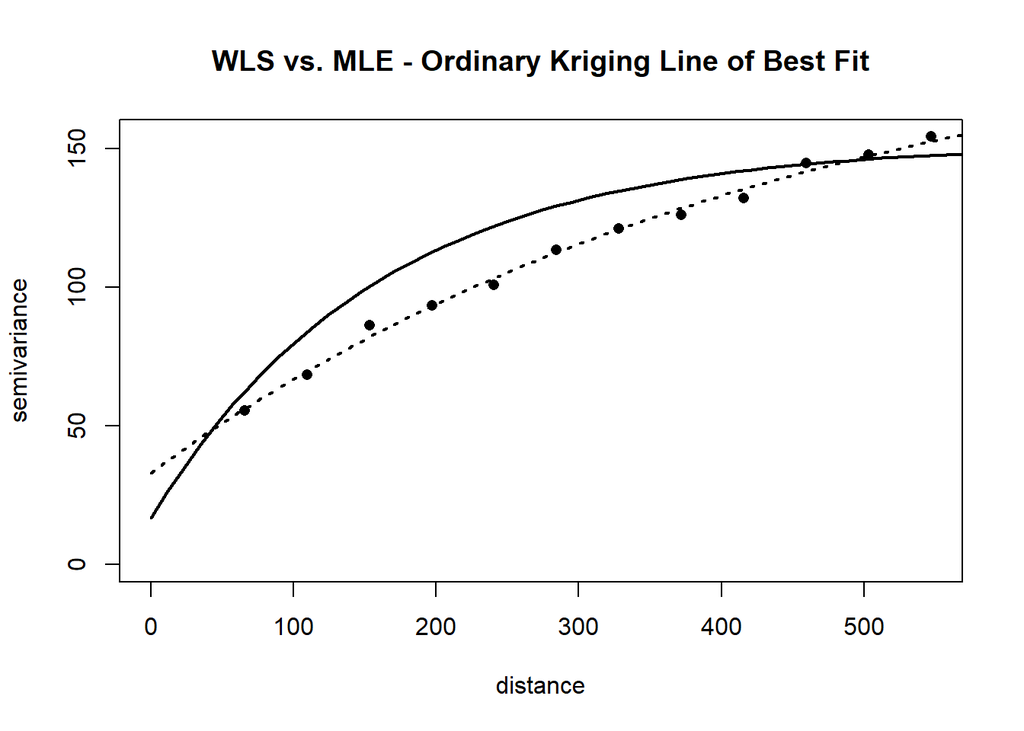

```r
lines(oklineofbestfitMLE, lwd = 2, lty = 1)

# Add legend and title. Solid line is MLE. Dashed line is WLS
title("WLS vs. MLE - Ordinary Kriging Line of Best Fit")
```

### Universal Kriging: Finding the line of best fit (MLE only)

As mentioned previously, in order to create the function to predict our outcome, we must first find out the function that best fits the semivariogram. In this case we need to find the function for the residul semivariogram after accounting for large-scale spatial variation using a linear regression model (aka land use regression model (LUR)).

```r
# Our first step is building the geodata object we want to use. The geodata object will be identical to the original 'ca20' geodata object apart from the covariates property, we want to keep altitude, remove area, and add the north portion of our coordinates
newCovariates = data.frame(north=as.vector(ca20$coords[,2]), altitude = as.vector(ca20$covariate$altitude))
newGeoDataObj = as.geodata(cbind(ca20$coords, ca20$data, newCovariates), covar.col = 4:5) # covar.coljust tells the function that our covariates are in columns 4 and 5

# Now we can fit our Universal Kriging Model using MLE (note MLE will be used on the residuals not the original data)
# Universal kriging (UK) is aslo known as 'kriging with a trend' (KT). The trend parameter in likfit() takes
uklineofbestfitMLE = likfit(newGeoDataObj, ini.cov.pars = c(50,100), nugget = 30, trend = trend.spatial(~north,newGeoDataObj), lik.method="ML") # we are ignoring the altitude covariate for convenience
```

```
## ---------------------------------------------------------------
## likfit: likelihood maximisation using the function optim.
## likfit: Use control() to pass additional
##          arguments for the maximisation function.
##         For further details see documentation for optim.
## likfit: It is highly advisable to run this function several
##         times with different initial values for the parameters.
## likfit: WARNING: This step can be time demanding!
## ---------------------------------------------------------------
## likfit: end of numerical maximisation.
```

```r
uklineofbestfitMLE$beta
```

```
##    intercept       covar1
## 193.54708183  -0.02737134
```

Now let’s see how well our uklineofbestfit line fits the residual semivariogram:

```r
vario_lm <-variog(geo_lm,max.dist=1138/2)
```

```
## variog: computing omnidirectional variogram
```

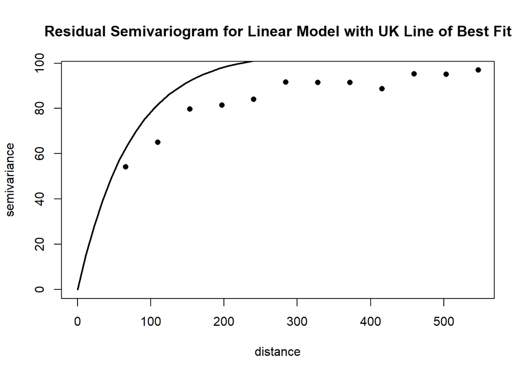

```r
plot(vario_lm,pch=16)
lines(uklineofbestfitMLE,lwd=2,lty=1)
title("Residual Semivariogram for Linear Model with UK Line of Best Fit")
```

### Creating the points at which we want a prediction

Let’s take a look at our data samples

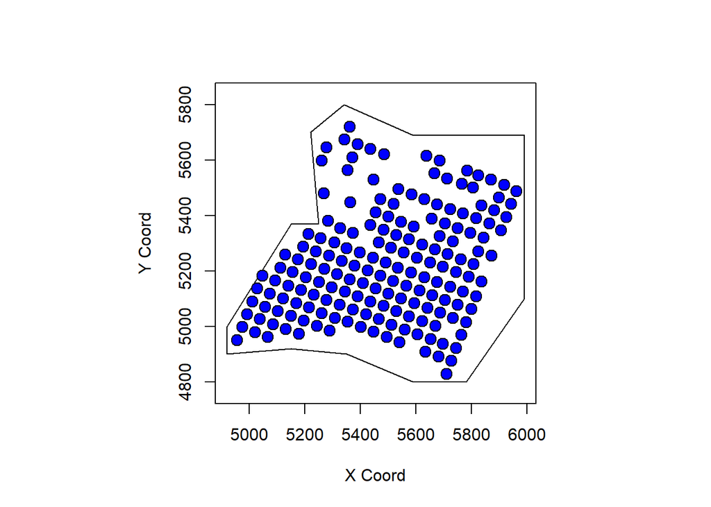

```r
# plot the calcium soil sample locations
points(ca20,pt.divide="equal",borders=ca20$borders,col=4)
```

```r
apply(ca20$coords,2,range)
```

```
##      east north
## [1,] 4957  4829
## [2,] 5961  5720
```

But the data above is our training data. we need a bunch of locations to predict at. Let’s create a dataframe of locations we want to predict at.

```r
# create a prediction grid
grid<-expand.grid(east=seq(4850,6050,length=75),
                  north=seq(4750,5850,length=75))

head(grid)
```

```
##       east north
## 1 4850.000  4750
## 2 4866.216  4750
## 3 4882.432  4750
## 4 4898.649  4750
## 5 4914.865  4750
## 6 4931.081  4750
```

Let’s us the ‘splancs’ package pip() function to subset these predictions by the borders of the dataset. These are the locations we are going to predict at:

```r
# Subset the prediction grid, and plot the sample locations and the prediction grid in one plot
grid2<-pip(grid,ca20$borders) # Pip is a finct
names(grid2)<-c("x","y")
grid3<- as.data.frame(grid2)
head(grid3)
```

```
##            x        y
## 346 5579.730 4809.459
## 347 5595.946 4809.459
## 348 5612.162 4809.459
## 349 5628.378 4809.459
## 350 5644.595 4809.459
## 351 5660.811 4809.459
```

### Predicting using our Universal Kriging Model

```r
# create a grid that adds north as a covariate
grid2X<-as.geodata(cbind(grid3,1,grid3[,2]),covar.col=4)# Note our geodata object has no 'data' property. That's because we want to predict our new data values, given a set of coordinate (coord) locations we want to find predictions at.
names(grid2X$covariate)<-"north"

univKrigPreds<-krige.conv(newGeoDataObj,locations=grid2,borders=newGeoDataObj$borders,
                         krige=krige.control(obj.model=uklineofbestfitMLE,
                                             trend.d=trend.spatial(~north,newGeoDataObj),
                                             trend.l=trend.spatial(~north,grid2X)))
```

```
## krige.conv: model with covariates matrix provided by the user
## krige.conv: Kriging performed using global neighbourhood
```

```r
class(univKrigPreds)
```

```
## [1] "kriging"
```

```r
# SHow the first few predictions
head(univKrigPreds$predict)
```

```
## [1] 61.20233 60.66595 60.02061 59.25663 58.36948 57.36561
```

Let’s see these predictions mapped:

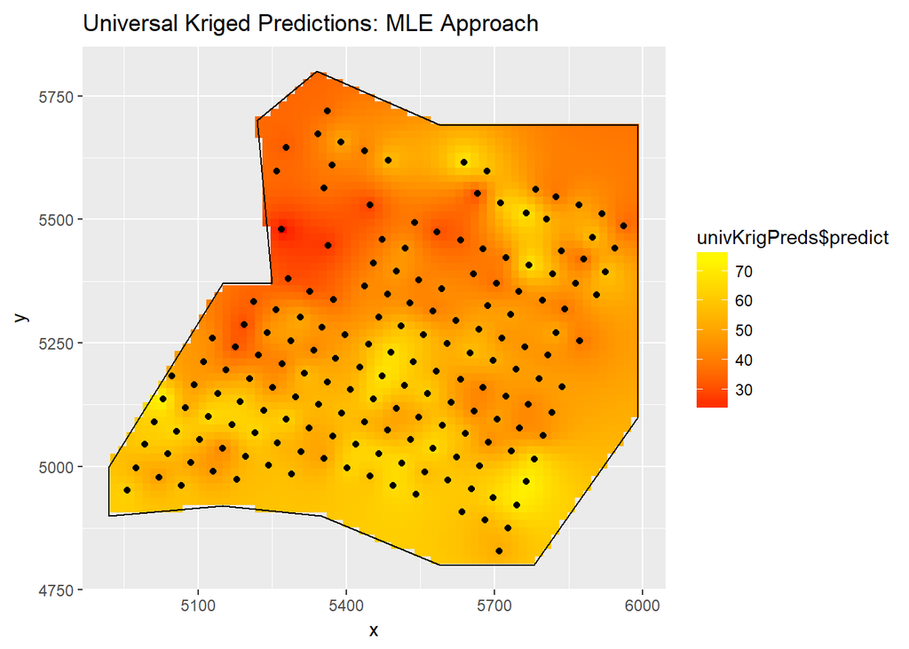

```r
sample_coords<- as.data.frame(ca20$coords)
sample_border<- as.data.frame(ca20$borders)
# visualize the krige.uk.mle kriging
ggplot(grid3, aes(x=x, y=y)) + geom_tile(aes(fill=univKrigPreds$predict)) +
  coord_equal() +
  scale_fill_gradient(low = "red", high="yellow") +
  geom_point(data = sample_coords, aes(x = east, y = north)) +
  geom_polygon(data = sample_border, aes(x = east, y = north), fill = NA, colour = 'black') +
  ggtitle('Universal Kriged Predictions: MLE Approach')
```